# Simulated VSD spectra

W. Bauer

May 31, 2015

### Stylized form of VSD spectra

This note is to specify an approximate model of VSD absorption and re-emission and the variation of those properties with membrane potential. Until exact data becomes available, I’ll rely on a stylized form as shown the example below.

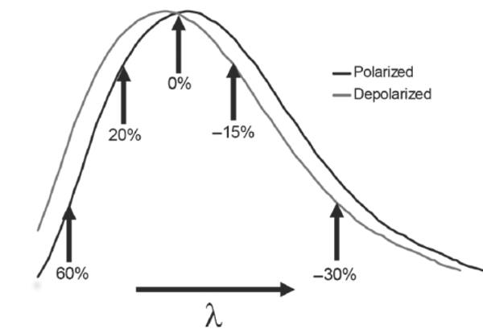

Source: L. M. Loew [Design and Use of Organic Voltage Sensitive Dyes](http://www.newbooks-services.de/MediaFiles/Texts/8/9781441965578_Excerpt_001.pdf) (ungated pdf).

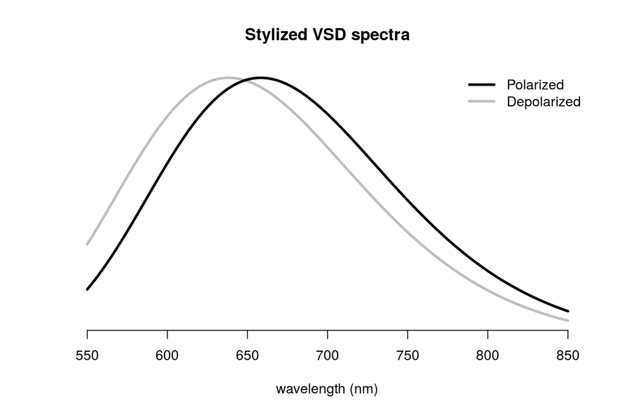

Peak emission and absorption wavelengths for various lipid-bound chromophores are given in Leslie Loew’s review, (*ibid*.) Spectrum bandwidths are not indicated in the review but widths of several hundred nanometers seem common elsewhere in the literature. Hence, my choice of +/- 150 nm above.

A convenient model based on the above can be created with the following code (which also appears in R/utilities.R.) Its use and interpretation are discussed below.

```r
# peak -- peak wavelength in nanometers
# width -- width (support) of the spectrum in nanometers
# Returns a function which gives relative fluorescence or absorption as a function of
# wavelength and shift due to depolarization.
vsdSpectrum <- function(peak, width=300){
   # Create a function for a curve with a 675 nm peak
  # NOTE: the factor 300/lambda^2 comes from a change of variable
  # from frequency to wavelength.
  fsd <- (300/(675-.5*width) - 300/675)/2.5
  fcal <- function(lambda)dnorm(300/lambda, 300/675, fsd)*300/lambda^2
  # Return a function which translates the calibrated curve
  # to the correct peak wavelength and shift, and normalizes
  # it so its peak value is 1.
  function(lambda, depolarization_shift=0){
    fcal(lambda + depolarization_shift + 675 - peak)/fcal(675)
  }
}
```

### Interpretation

For simulations, I’ll assume that voltage-induced variations in an absorption spectrum correspond to proportional variations in a dye’s absorption coefficient, $\mu_a.$ Thus, if depolarization causes a -15% change in the absorption spectrum at a certain wavelength, I’ll assume the absorption coefficient changes by -15% as well.

I’ve [estimated](http://brain-initiative.github.io/know_brainR/Rmds/absorption.html) that absorption coefficients of 1 micromolar concentrations of VSD will be about the same as those of gray matter. In this case, a variation of -15% in a dye’s coefficient would result in a -7.5% variation in the region’s.

After dye absorbs a photon, it will lose some energy through vibration then either emit a photon at a longer wavelength or relax entirely through heat. If it re-emits a photon, it will do so at a longer wavelength as governed by its *emission* spectrum. Interpreting its emission spectrum as a curve of relative emission rates, the mean wavelength of re-emission can be calculated as if the spectrum were a probability distribution:$E\left(\lambda_{em}\right) = \frac{\int_{\lambda_{abs}}^{\infty}\lambda S_{em}(\lambda)d\lambda}{\int_{\lambda_{abs}}^{\infty}S_{em}(\lambda)d\lambda}$

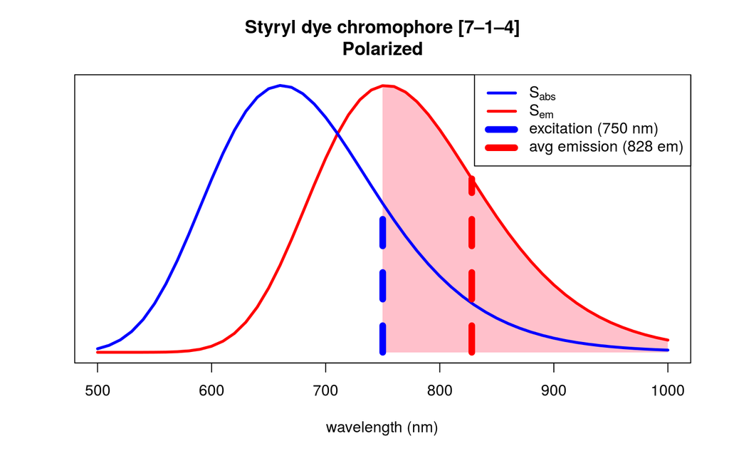

If depolarization shifts both spectra to the left by 30 nm, the excitation remains the same, but the average re-emission wavelength decreases to 820 nm, resulting in re-emission loss of $1 - 750/820 \approx 0.085$, about 1% less than before. (Of course, absorption will decrease, in this case, by about 32%, so total emitted energy, optical plus acoustic, will decrease by a similar amount.)

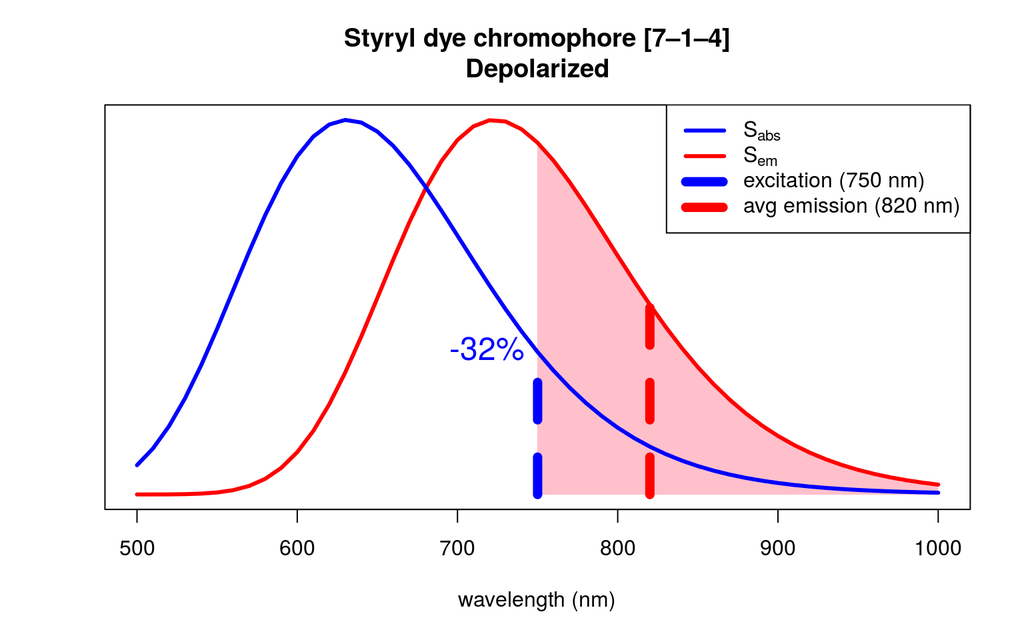